# Analysis_2016_Presidential_Campaign_Contribution _NY_Data Exploration.rmd

Moh.A.T.Elgaser

31/01/2019

**Explore data for New York city (New York city)**

```r
# Load Dataset into Workspace.

# ny = read.csv('P00000001-ny.csv')

# When loading CSV file, I got an error of "Error in read.csv : duplicate 'row.names' are not allowed".  After doing some research and this blog post at StackOverflow, I found the solution by adding a "," to the end of the header line.  This however, added an additional column.
# function to overcome the problem that number of header fields less than number of columns below the header row.

myread <- function(file, sep = ",", ...){
    nm <- readLines(file, n = 1)
    nm <- unlist(strsplit(nm, sep))
    DF <- read.table(file, skip = 1, sep = sep, ...)
    if(length(names(DF)) > length(nm)){
        names(DF)[(length(names(DF)) - length(nm) + 1):length(names(DF))] <- nm
    } else names(DF) <- nm
    DF
}

ny <- myread("P00000001-NY.csv", sep = ",")


head(ny,3)
```

```
##          V1   cmte_id                 cand_id              cand_nm
## 1 C00575795 P00003392 Clinton, Hillary Rodham JONES TAKATA, LOUISE
## 2 C00575795 P00003392 Clinton, Hillary Rodham           CODY, ERIN
## 3 C00577130 P60007168        Sanders, Bernard       KEITH, SUSAN H
##   contbr_nm contbr_city contbr_st                          contbr_zip
## 1  NEW YORK          NY 100162783                                 N/A
## 2   BUFFALO          NY 142221910 RUPP BAASE PFALZGRAF CUNNINGHAM LLC
## 3  NEW YORK          NY 100133107                        NOT EMPLOYED
##   contbr_employer contbr_occupation contb_receipt_amt contb_receipt_dt
## 1         RETIRED            100.00         15-APR-16
## 2        ATTORNEY             66.95         24-APR-16
## 3    NOT EMPLOYED             50.00         06-MAR-16
##   receipt_desc                             memo_cd memo_text form_tp
## 1            X              * HILLARY VICTORY FUND      SA18 1091718
## 2            X              * HILLARY VICTORY FUND      SA18 1091718
## 3              * EARMARKED CONTRIBUTION: SEE BELOW     SA17A 1077404
##      file_num tran_id election_tp
## 1    C4732422   P2016          NA
## 2    C4752463   P2016          NA
## 3 VPF7BKZ1KR1   P2016          NA
```

**TO rename columns name**

```r
colnames(ny) <- c('cmte_id','cand_id','cand_nm','contbr_nm','contbr_city','contbr_st','contbr_zip','contbr_employer','contbr_occupation','contb_receipt_amt','contb_receipt_dt','receipt_desc','memo_cd','memo_text','form_tp=ny','file_num','tran_id=ny','election_tp','v1')

head(ny,3)
```

```
##     cmte_id   cand_id                 cand_nm            contbr_nm
## 1 C00575795 P00003392 Clinton, Hillary Rodham JONES TAKATA, LOUISE
## 2 C00575795 P00003392 Clinton, Hillary Rodham           CODY, ERIN
## 3 C00577130 P60007168        Sanders, Bernard       KEITH, SUSAN H
##   contbr_city contbr_st contbr_zip                     contbr_employer
## 1    NEW YORK        NY  100162783                                 N/A
## 2     BUFFALO        NY  142221910 RUPP BAASE PFALZGRAF CUNNINGHAM LLC
## 3    NEW YORK        NY  100133107                        NOT EMPLOYED
##   contbr_occupation contb_receipt_amt contb_receipt_dt receipt_desc
## 1           RETIRED            100.00        15-APR-16
## 2          ATTORNEY             66.95        24-APR-16
## 3      NOT EMPLOYED             50.00        06-MAR-16
##   memo_cd                           memo_text form_tp=ny file_num
## 1       X              * HILLARY VICTORY FUND       SA18  1091718
## 2       X              * HILLARY VICTORY FUND       SA18  1091718
## 3         * EARMARKED CONTRIBUTION: SEE BELOW      SA17A  1077404
##    tran_id=ny election_tp v1
## 1    C4732422       P2016 NA
## 2    C4752463       P2016 NA
## 3 VPF7BKZ1KR1       P2016 NA
```

**what v1 column have?**

```r
levels(ny$v1)
```

**TO REMVE column v1 where all values NA values**

```r
ny= subset(ny,select = (-v1))
head(ny,3)
```

```
##     cmte_id   cand_id                 cand_nm            contbr_nm
## 1 C00575795 P00003392 Clinton, Hillary Rodham JONES TAKATA, LOUISE
## 2 C00575795 P00003392 Clinton, Hillary Rodham           CODY, ERIN
## 3 C00577130 P60007168        Sanders, Bernard       KEITH, SUSAN H
##   contbr_city contbr_st contbr_zip                     contbr_employer
## 1    NEW YORK        NY  100162783                                 N/A
## 2     BUFFALO        NY  142221910 RUPP BAASE PFALZGRAF CUNNINGHAM LLC
## 3    NEW YORK        NY  100133107                        NOT EMPLOYED
##   contbr_occupation contb_receipt_amt contb_receipt_dt receipt_desc
## 1           RETIRED            100.00        15-APR-16
## 2          ATTORNEY             66.95        24-APR-16
## 3      NOT EMPLOYED             50.00        06-MAR-16
##   memo_cd                           memo_text form_tp=ny file_num
## 1       X              * HILLARY VICTORY FUND       SA18  1091718
## 2       X              * HILLARY VICTORY FUND       SA18  1091718
## 3         * EARMARKED CONTRIBUTION: SEE BELOW      SA17A  1077404
##    tran_id=ny election_tp
## 1    C4732422       P2016
## 2    C4752463       P2016
## 3 VPF7BKZ1KR1       P2016
```

**what are the mean of the abbreviation’s in NY data set ?**

```r
# CMTE_ID ------>           COMMITTEE ID
# CAND_ID   ------>       CANDIDATE ID
# CAND_NM   ------>       CANDIDATE NAME
# contbr_nm ------>   Contributor/Lender/Transfer Name: Contributor Name
# contbr_city------>  City/Town: Contributor City
# contbr_st ------>   State: Contributor State
# contbr_zip ------>  Zip Code: Contributor Zip Code
# contbr_employer --->Employer: Contributor's Employer
# contbr_occupation-->Occupation: Contributor's Occupation
# contb_receipt_amt-->Transaction Amount:
# contb_receipt_dt--->Transaction Date(MMDDYYYY):
# RECIPIENT_NM------>   RECIPIENT NAME
# DISB_AMT ------>      DISBURSEMENT AMOUNT
# DISB_DT------>      DISBURSEMENT DATE
# RECIPIENT_CITY---->   RECIPIENT CITY
# RECIPIENT_ST------>   RECIPIENT STATE
# RECIPIENT_ZIP------>RECIPIENT ZIPE CODE
# DISB_DESC------>    DISBURSEMENT DESCRIPTION
# MEMO_CD------>      MEMO CODE 'X' indicates that the amount is NOT to be                                      included in the itemization total.
# MEMO_TEXT------>    MEMO TEXT  A description of the activity. Memo Text is available on itemized amounts on Schedules A and B. These transactions are included in the itemization total                      .
# FORM_TP------>      FEC FORM TYPE
# FILE_NUM------>     FILE NUMBER   or  Report ID is Unique report id
# TRAN_ID------>      TRANSACTION ID    ONLY VALID FOR ELECTRONIC FILINGS. A unique identifier associated with each itemization or transaction appearing in an FEC electronic file. A transaction ID is unique for a specific committee for a specific report. In other words, if committee, C1, files a Q3 New with transaction SA123 and then files 3 amendments to the Q3 transaction SA123 will be identified.

#ELECTION_TP------>    This code indicates the election for which the contribution was made. EYYYY (election Primary, General,Other plus election year)
```

*This is a report on data exploration with a dataset of 2016 presidential campaign contribution data for NEW YORK state.The dataset contains 649460 observation and 18 variables*

*what NY data looks?*

```
##     cmte_id   cand_id                 cand_nm            contbr_nm
## 1 C00575795 P00003392 Clinton, Hillary Rodham JONES TAKATA, LOUISE
## 2 C00575795 P00003392 Clinton, Hillary Rodham           CODY, ERIN
## 3 C00577130 P60007168        Sanders, Bernard       KEITH, SUSAN H
##   contbr_city contbr_st contbr_zip                     contbr_employer
## 1    NEW YORK        NY  100162783                                 N/A
## 2     BUFFALO        NY  142221910 RUPP BAASE PFALZGRAF CUNNINGHAM LLC
## 3    NEW YORK        NY  100133107                        NOT EMPLOYED
##   contbr_occupation contb_receipt_amt contb_receipt_dt receipt_desc
## 1           RETIRED            100.00        15-APR-16
## 2          ATTORNEY             66.95        24-APR-16
## 3      NOT EMPLOYED             50.00        06-MAR-16
##   memo_cd                           memo_text form_tp=ny file_num
## 1       X              * HILLARY VICTORY FUND       SA18  1091718
## 2       X              * HILLARY VICTORY FUND       SA18  1091718
## 3         * EARMARKED CONTRIBUTION: SEE BELOW      SA17A  1077404
##    tran_id=ny election_tp
## 1    C4732422       P2016
## 2    C4752463       P2016
## 3 VPF7BKZ1KR1       P2016
```

```
##          cmte_id   cand_id                 cand_nm         contbr_nm
## 649458 C00575795 P00003392 Clinton, Hillary Rodham  HARRISON, MYCHAL
## 649459 C00575795 P00003392 Clinton, Hillary Rodham      LEVIN, SARAH
## 649460 C00575795 P00003392 Clinton, Hillary Rodham FRANCE, PARAMELLE
##         contbr_city contbr_st contbr_zip contbr_employer contbr_occupation
## 649458     NEW YORK        NY  102827021
## 649459 POUGHKEEPSIE        NY  126040001
## 649460     NEW YORK        NY  100053574
##        contb_receipt_amt contb_receipt_dt receipt_desc memo_cd memo_text
## 649458               -15        15-OCT-16       Refund
## 649459               -50        07-OCT-16       Refund
## 649460               -10        18-OCT-16       Refund
##        form_tp=ny file_num tran_id=ny election_tp
## 649458      SB28A  1137788    D310725       G2016
## 649459      SB28A  1137788    D299995       G2016
## 649460      SB28A  1137788    D312997       G2016
```

*what the structure of NY data set?*

```
## 'data.frame':    649460 obs. of  18 variables:
##  $ cmte_id          : Factor w/ 25 levels "C00458844","C00500587",..: 6 6 7 7 6 7 7 6 6 15 ...
##  $ cand_id          : Factor w/ 25 levels "P00003392","P20002671",..: 1 1 12 12 1 12 12 1 1 23 ...
##  $ cand_nm          : Factor w/ 25 levels "Bush, Jeb","Carson, Benjamin S.",..: 4 4 20 20 4 20 20 4 4 23 ...
##  $ contbr_nm        : Factor w/ 119407 levels "'CALLAHAN, BARBARA",..: 52364 19422 54646 61896 8862 63027 63080 54730 55289 91553 ...
##  $ contbr_city      : Factor w/ 2327 levels "","'CALLICOON",..: 1425 287 1425 269 1620 1407 1644 1425 595 1425 ...
##  $ contbr_st        : Factor w/ 1 level "NY": 1 1 1 1 1 1 1 1 1 1 ...
##  $ contbr_zip       : Factor w/ 69031 levels "","`1136","00000",..: 7189 64481 5944 40224 58462 30808 49151 5407 62866 69031 ...
##  $ contbr_employer  : Factor w/ 39303 levels "","'SELF'","'TRANSPARENT'",..: 23094 30024 24572 24036 16446 24886 33394 30941 23094 16446 ...
##  $ contbr_occupation: Factor w/ 17219 levels "","''RETIRED''",..: 13288 1249 10333 16184 7896 15445 12064 16984 13288 7896 ...
##  $ contb_receipt_amt: num  100 67 50 15 100 ...
##  $ contb_receipt_dt : Factor w/ 697 levels "01-APR-15","01-APR-16",..: 316 524 126 81 250 103 103 408 160 22 ...
##  $ receipt_desc     : Factor w/ 27 levels ""," SEE REATTRIBUTION",..: 1 1 1 1 1 1 1 1 1 1 ...
##  $ memo_cd          : Factor w/ 2 levels "","X": 2 2 1 1 2 1 1 2 2 2 ...
##  $ memo_text        : Factor w/ 262 levels ""," SEE REATTRIBUTION",..: 83 83 55 55 83 55 55 83 83 1 ...
##  $ form_tp=ny       : Factor w/ 3 levels "SA17A","SA18",..: 2 2 1 1 2 1 1 2 2 2 ...
##  $ file_num         : int  1091718 1091718 1077404 1077404 1091718 1077404 1077404 1091718 1091718 1146165 ...
##  $ tran_id=ny       : Factor w/ 648415 levels "A00136D649BB94F13985",..: 275346 275731 533152 531094 275039 532242 531783 275424 274830 450800 ...
##  $ election_tp      : Factor w/ 6 levels "","G2016","O2016",..: 5 5 5 5 5 5 5 5 5 2 ...
```

*Here is the summary of the dataset:*

```
##       cmte_id            cand_id                            cand_nm
##  C00575795:399522   P00003392:399522   Clinton, Hillary Rodham  :399522
##  C00577130:174564   P60007168:174564   Sanders, Bernard         :174564
##  C00580100: 36931   P80001571: 36931   Trump, Donald J.         : 36931
##  C00574624: 16785   P60006111: 16785   Cruz, Rafael Edward 'Ted': 16785
##  C00573519:  6638   P60005915:  6638   Carson, Benjamin S.      :  6638
##  C00458844:  4813   P60006723:  4813   Rubio, Marco             :  4813
##  (Other)  : 10207   (Other)  : 10207   (Other)                  : 10207
##              contbr_nm             contbr_city     contbr_st
##  BODNICK, KATIE   :  1326   NEW YORK     :206993   NY:649460
##  BRUN, GINA       :   413   BROOKLYN     : 86953
##  BRONER, NAHAMA   :   318   BRONX        : 14102
##  SCHWARTZ, HILARY :   311   ROCHESTER    :  9985
##  KILLORIN, MICHAEL:   310   STATEN ISLAND:  7431
##  GRODY, GORDON    :   307   BUFFALO      :  6196
##  (Other)          :646475   (Other)      :317800
##      contbr_zip          contbr_employer               contbr_occupation
##  100015704:  1332   N/A          : 82294   RETIRED              : 98667
##  10024    :  1197   SELF-EMPLOYED: 67025   NOT EMPLOYED         : 47994
##  10022    :   871   RETIRED      : 42105   ATTORNEY             : 26486
##  10023    :   864   NONE         : 32333   INFORMATION REQUESTED: 16956
##  10025    :   829   NOT EMPLOYED : 21881   TEACHER              : 15080
##  10128    :   745   (Other)      :403497   (Other)              :444199
##  (Other)  :643622   NA's         :   325   NA's                 :    78
##  contb_receipt_amt   contb_receipt_dt                      receipt_desc
##  Min.   :  -10100   06-NOV-16:  6125                             :641311
##  1st Qu.:      15   31-OCT-16:  5924   Refund                    :  5994
##  Median :      27   26-SEP-16:  5922   REDESIGNATION TO GENERAL  :   406
##  Mean   :     264   02-NOV-16:  5908   REDESIGNATION FROM PRIMARY:   404
##  3rd Qu.:     100   04-NOV-16:  5814   REATTRIBUTION FROM SPOUSE :   221
##  Max.   :12777706   31-MAR-16:  5768   REATTRIBUTION TO SPOUSE   :   221
##                     (Other)  :613999   (Other)                   :   903
##  memo_cd                                  memo_text      form_tp=ny
##   :541113                                      :398114   SA17A:537819
##  X:108347   * EARMARKED CONTRIBUTION: SEE BELOW:170844   SA18 :105647
##             * HILLARY VICTORY FUND             : 75710   SB28A:  5994
##             *BEST EFFORTS UPDATE               :   773
##             * HILLARY ACTION FUND              :   572
##             REDESIGNATION TO GENERAL           :   406
##             (Other)                            :  3041
##     file_num            tran_id=ny     election_tp
##  Min.   :1003942   SA17A.4846:     3        :   690
##  1st Qu.:1079445   C10000499 :     2   G2016:271367
##  Median :1104813   C10000663 :     2   O2016:   237
##  Mean   :1105477   C10091902 :     2   P2015:     1
##  3rd Qu.:1133832   C1013282  :     2   P2016:377162
##  Max.   :1146285   C1014914  :     2   P2020:     3
##                    (Other)   :649447
```

## *NOTE*

1-*Is`cmte_id` designated especially for each election candidate `cand_nm`/`cand_id`since`cmte_id`,`cand_id`and`cand_nm` has the same counts?*

2-*`contb_receipt_amt` shows a negative value - Why is that?*

3-*How far back do contributions start coming in?*

4-*Is there any trend over time?*

5-*What cities did the contributions came from?*

6-*What party’s candidates get more contributions?*

7-*Which candidates received highest amount and counts of contribution in NEW YORK?*

*From data structure and data sammary we going to answer some questions to under stand data set using different types of visualizition*

## *Univariate Plots*

__

*1-How many COMMITTEE id -`cmte_id` Data set have?*

```
## [1] 25
```

*2-what Is the ranking of COMMITTEEs according to number of contributions*

```
## C00575795 C00577130 C00580100 C00574624 C00573519 C00458844 C00579458
##    399522    174564     36931     16785      6638      4813      2436
## C00581876 C00577312 C00575449 C00581199 C00605568 C00580399 C00578757
##      1350      1218      1141      1001       782       486       362
## C00578658 C00580480 C00577981 C00578245 C00583146 C00623884 C00578492
##       343       265       254       182       116       103        69
## C00581215 C00500587 C00580159 C00582668
##        46        27        21         5
```

*plotting show ranking of COMMITTEEs according to number of contributions*

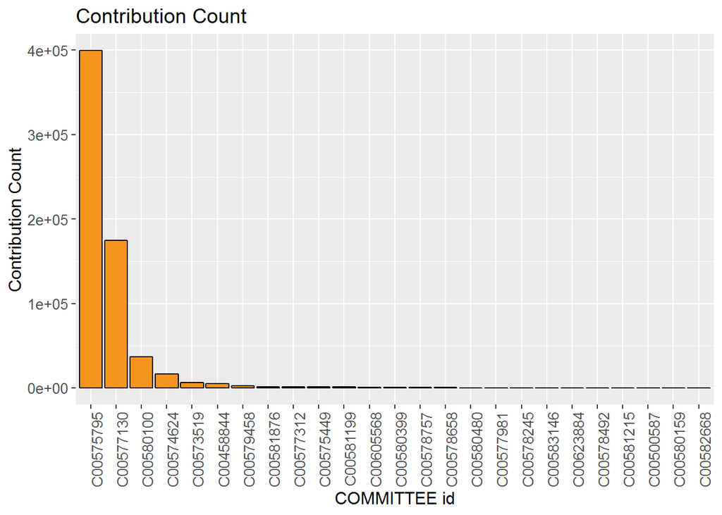

*we are going to use log10 to to make skewed more clear*

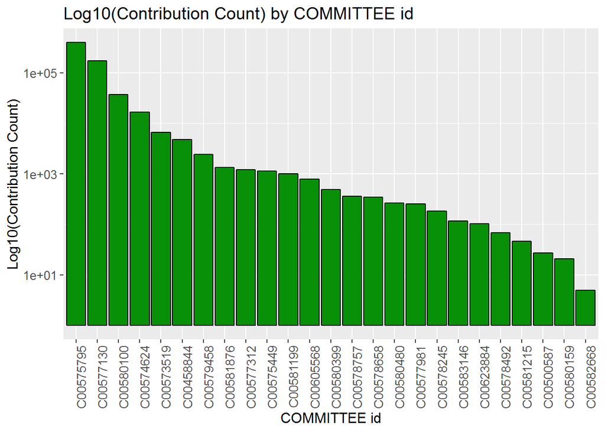

#### *Observations*

it is clear most contributions occur for specific committees specially

*C00575795 399522, C00577130 174564 ,C00580100 36931,C00574624,16785*

*by searching for this committees*

> 1.C00575795 is HILLARY FOR AMERICA - PRINCIPAL CAMPAIGN COMMITTEE OF HILLARY*

> 3.C00580100 is DONALD J. TRUMP FOR PRESIDENT, INC PRINCIPAL CAMPAIGN COMMITTEE OF TRUMP  
> *> 4.C00574624 is CRUZ FOR PRESIDENT P - PRINCIPAL CAMPAIGN COMMITTEE OF CRUZ*

*1-from the summary `cand_id` and `cand_nm` has the same level counts.*

### Candidate Name `cand_nm`

*How many candidates are compite in presidential election’s ?*

```
## [1] 25
```

*what are presidential election’s candidates names ?*

```
##  [1] Clinton, Hillary Rodham   Sanders, Bernard
##  [3] Trump, Donald J.          O'Malley, Martin Joseph
##  [5] Cruz, Rafael Edward 'Ted' Walker, Scott
##  [7] Bush, Jeb                 Rubio, Marco
##  [9] Kasich, John R.           Christie, Christopher J.
## [11] Stein, Jill               Johnson, Gary
## [13] Graham, Lindsey O.        Webb, James Henry Jr.
## [15] Carson, Benjamin S.       Paul, Rand
## [17] Fiorina, Carly            Santorum, Richard J.
## [19] Jindal, Bobby             Huckabee, Mike
## [21] Pataki, George E.         Gilmore, James S III
## [23] Lessig, Lawrence          Perry, James R. (Rick)
## [25] McMullin, Evan
## 25 Levels: Bush, Jeb Carson, Benjamin S. ... Webb, James Henry Jr.
```

*How many contributions are for every presidential election’s candidates in data set ?*

```
##   Clinton, Hillary Rodham          Sanders, Bernard
##                    399522                    174564
##          Trump, Donald J. Cruz, Rafael Edward 'Ted'
##                     36931                     16785
##       Carson, Benjamin S.              Rubio, Marco
##                      6638                      4813
##                 Bush, Jeb           Kasich, John R.
##                      2436                      1350
##            Fiorina, Carly                Paul, Rand
##                      1218                      1141
##               Stein, Jill             Johnson, Gary
##                      1001                       782
##  Christie, Christopher J.        Graham, Lindsey O.
##                       486                       362
##   O'Malley, Martin Joseph             Walker, Scott
##                       343                       265
##            Huckabee, Mike         Pataki, George E.
##                       254                       182
##          Lessig, Lawrence            McMullin, Evan
##                       116                       103
##      Santorum, Richard J.     Webb, James Henry Jr.
##                        69                        46
##    Perry, James R. (Rick)             Jindal, Bobby
##                        27                        21
##      Gilmore, James S III
##                         5
```

### plotting of contributions for every presidential election’s candidates

Transform y scale to make skewed data close to normal

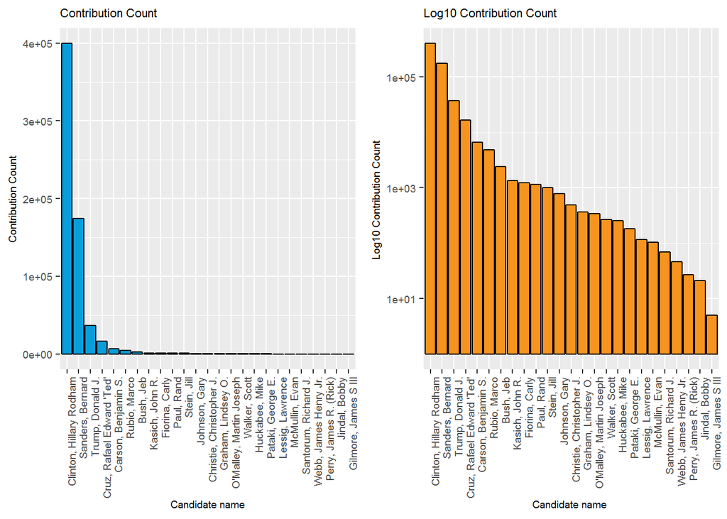

*How we can clasifiy count of contributions and proportion for every presidential election’s candidates ?*

```
## # A tibble: 25 x 3
##    cand_nm                        n proportion
##    <fct>                      <int>      <dbl>
##  1 Clinton, Hillary Rodham   399522    0.615
##  2 Sanders, Bernard          174564    0.269
##  3 Trump, Donald J.           36931    0.0569
##  4 Cruz, Rafael Edward 'Ted'  16785    0.0258
##  5 Carson, Benjamin S.         6638    0.0102
##  6 Rubio, Marco                4813    0.00741
##  7 Bush, Jeb                   2436    0.00375
##  8 Kasich, John R.             1350    0.00208
##  9 Fiorina, Carly              1218    0.00188
## 10 Paul, Rand                  1141    0.00176
## # ... with 15 more rows
```

*we are going to clasifiy the into 4 groups:*  
–>*less than 1000 contribution*  
–>*more than 1000 and less than or equal to 10000*  
–>*more than 10000and less than or equal to 100000*  
–>*more than 100000*

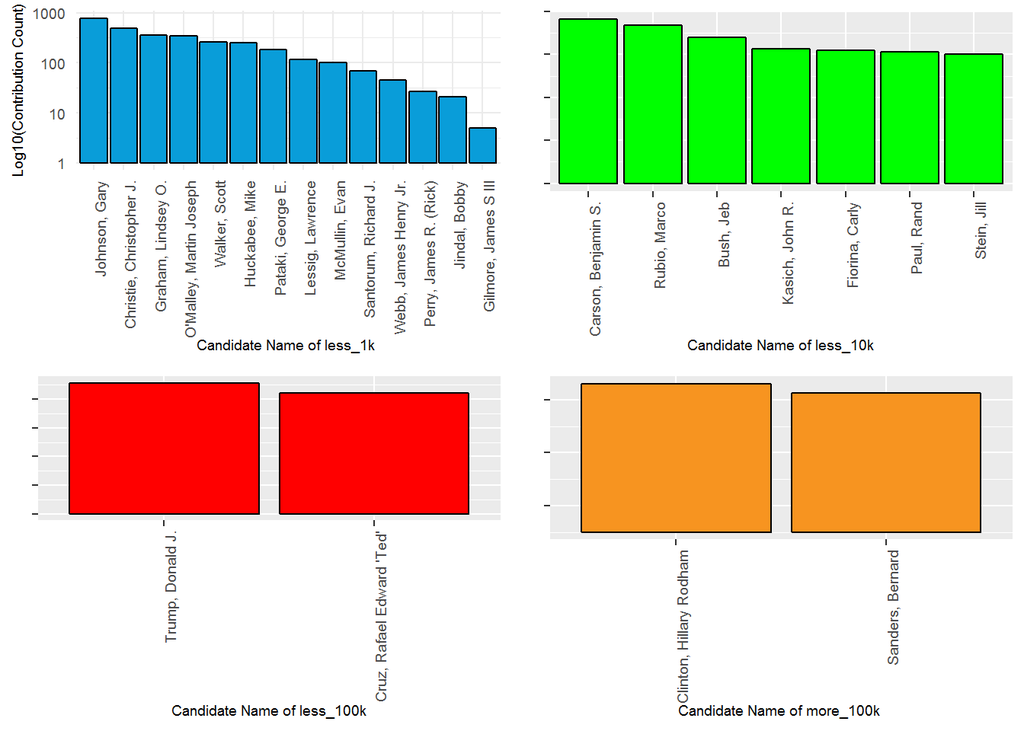

*What are ranking of count contributions proportion according to presidential election’s candidates*

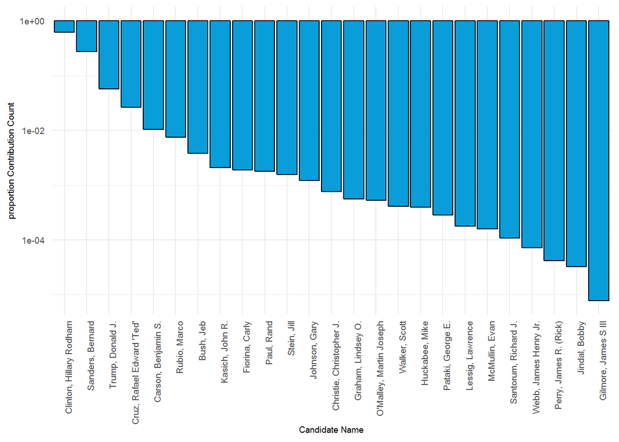

*classifiying proportion of contributions for every presidential election’s candidates ?*

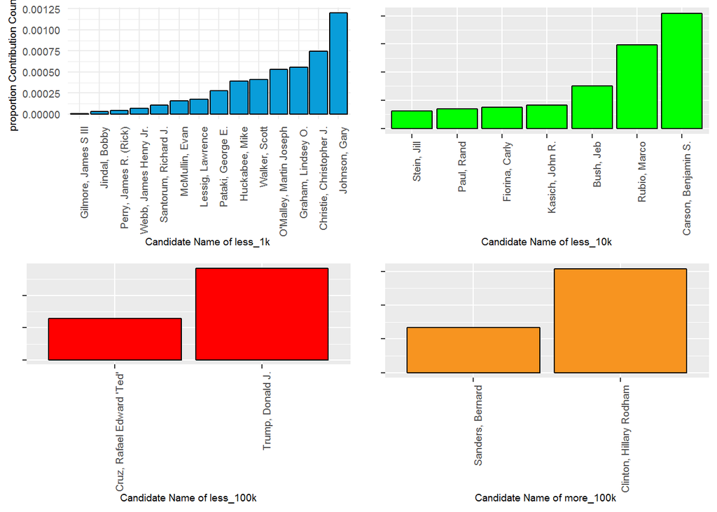

#### **Observations**

There are 25 distinct candidates. We see the counts of contribution transactions received by 25 candidates varies dramatically.  
The plots show that:

candidates have more than 100,000 contributions  
–> Clinton, Hillary Rodham 399522  
–> Sanders, Bernard 174564

–> 7 candidates have less than 10000 contributions  
–> 14 candidates have less than 1000 contributions

### Contributor Name `contbr_nm`

*How many contributer NY data set have ?*

```
## [1] 119407
```

There are 119407 distinict contributors, by names.

*what are ranking of contributions amount by contributers in NY state*

```
## # A tibble: 119,407 x 4
##    contbr_nm                     contbr_nm.rank count_of_contrib proportion
##    <fct>                                  <dbl>            <int>      <dbl>
##  1 HILLARY VICTORY FUND - UNITE~      80675920.               23  0.470
##  2 PATAKI, GEORGE E                      30278.                5  0.000176
##  3 JONAS, HOWARD MR.                     20800                10  0.000121
##  4 LYONS, JOHN                           19200                12  0.000112
##  5 STEINLAUF, RONALD                     17800                16  0.000104
##  6 COHEN, JONATHAN                       17225                17  0.000100
##  7 JONAS, DEBBIE MRS.                    15400                 7  0.0000897
##  8 ISAAC, PAUL J. MR.                    14500                13  0.0000845
##  9 ELSANT, MARTIN                        14200                14  0.0000827
## 10 ALPERN, HARLAN                        13500                 4  0.0000786
## # ... with 119,397 more rows
```

*Ranking of top 20 contributers according to contribution amount in NY .state*

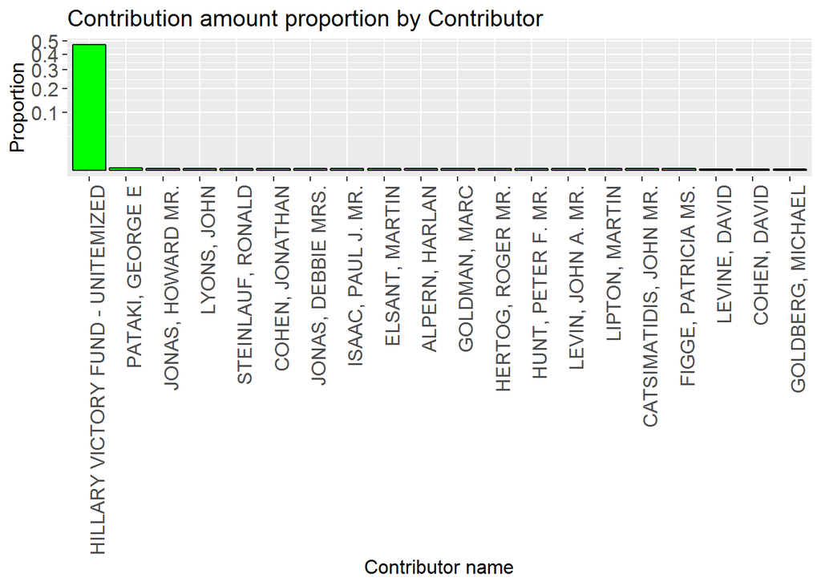

#### **Observations**

> There are 119407 distint contributors HILLARY VICTORY FUND - UNITEMIZED dramatically contribute by almost 47% of total contributions in New York state

*what are the Contributions by party ?*

```
##  Democratic  Republican       Green Libertarian Independent
##      574591       72983        1001         782         103
```

*plotting the distribution of Contributions by party*

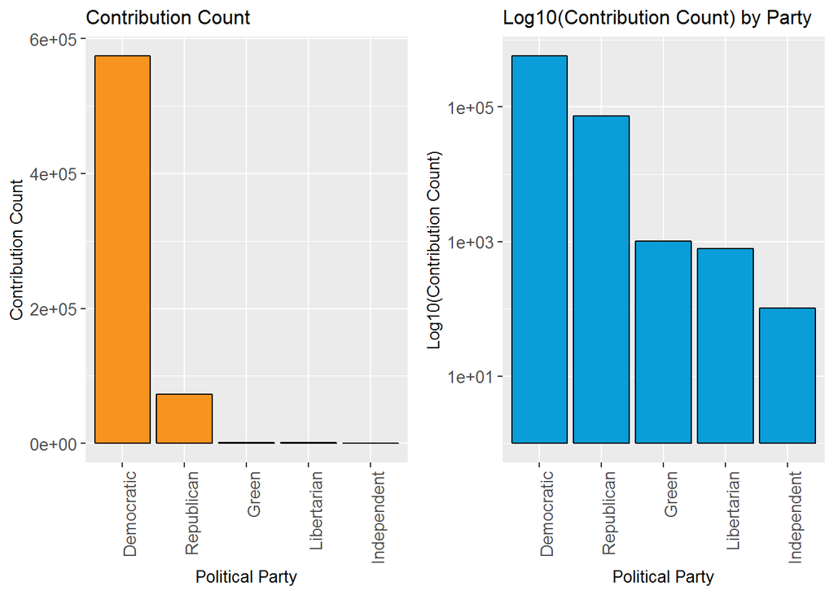

*what is the proportion of Contribution count by cand_party ?*

```
## # A tibble: 5 x 3
##   cand_party       n proportion
##   <fct>        <int>      <dbl>
## 1 Democratic  574591   0.885
## 2 Republican   72983   0.112
## 3 Green         1001   0.00154
## 4 Libertarian    782   0.00120
## 5 Independent    103   0.000159
```

*plotting of proportion of Contribution count by cand_party*

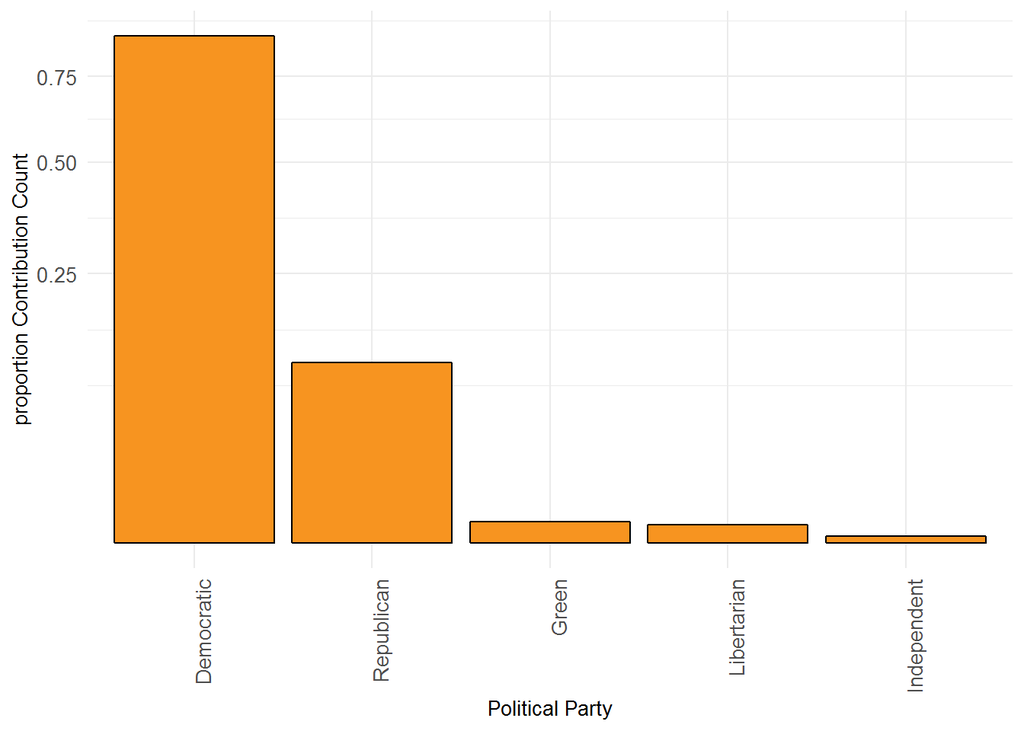

#### **Observations**

> We see the counts of contribution transactions received by parties vary dramatically proportional count number of contributions for Democratic party more than all other parties contributions

*what are the proportion of contributions count by every unique Contributors ? `*

```
## # A tibble: 119,407 x 3
##    contbr_nm                    n proportion
##    <fct>                    <int>      <dbl>
##  1 BODNICK, KATIE            1326   0.00204
##  2 BRUN, GINA                 413   0.000636
##  3 BRONER, NAHAMA             318   0.000490
##  4 SCHWARTZ, HILARY           311   0.000479
##  5 KILLORIN, MICHAEL          310   0.000477
##  6 GRODY, GORDON              307   0.000473
##  7 SWIRE, JAMES BENNETT MR.   290   0.000447
##  8 NAZIR, MOHAMMAD            253   0.000390
##  9 LANSDALE, JOHN             241   0.000371
## 10 KASS, MARTIN DR.           218   0.000336
## # ... with 119,397 more rows
```

> since number of contributors are 119407 so we will analysise it in more details later

### Contribution Receipt Date, `contb_receipt_dt`

*What Contribution Receipt Date data look ?*

```
##   (Other) 06-NOV-16 31-OCT-16 26-SEP-16 02-NOV-16 04-NOV-16 31-MAR-16
##    324906      6125      5924      5922      5908      5814      5768
## 07-NOV-16 01-NOV-16 03-NOV-16 29-OCT-16 19-OCT-16 29-FEB-16 31-MAY-16
##      5632      5631      5513      5385      5271      5156      5010
## 30-SEP-16 05-NOV-16 30-APR-16 09-OCT-16 30-OCT-16 14-MAR-16 09-MAR-16
##      4970      4651      4573      4306      4293      4103      3965
## 12-JUL-16 28-JUL-16 28-OCT-16 30-JUN-16 15-SEP-16 27-SEP-16 08-APR-16
##      3780      3765      3764      3741      3707      3692      3682
## 21-JUL-16 31-AUG-16 06-APR-16 30-MAR-16 08-NOV-16 08-JUN-16 29-JUL-16
##      3639      3634      3617      3573      3571      3511      3434
## 29-SEP-16 26-OCT-16 16-MAR-16 27-OCT-16 20-APR-16 29-APR-16 25-OCT-16
##      3412      3363      3240      3219      3209      3152      3139
## 15-APR-16 17-OCT-16 14-APR-16 14-OCT-16 18-OCT-16 29-MAR-16 04-MAY-16
##      3114      3091      3076      3058      3029      2978      2974
## 09-AUG-16 20-OCT-16 03-MAY-16 10-OCT-16 28-SEP-16 20-SEP-16 24-OCT-16
##      2927      2924      2871      2813      2806      2801      2800
## 19-JUL-16 29-JUN-16 10-FEB-16 26-JUL-16 23-SEP-16 11-JUL-16 05-APR-16
##      2778      2758      2739      2731      2729      2717      2711
## 07-OCT-16 31-JUL-16 13-APR-16 08-SEP-16 12-AUG-16 07-SEP-16 08-OCT-16
##      2673      2643      2618      2592      2551      2540      2534
## 20-JUL-16 14-SEP-16 16-SEP-16 09-FEB-16 04-OCT-16 08-AUG-16 22-JUL-16
##      2473      2469      2420      2411      2393      2388      2381
## 25-JUL-16 12-OCT-16 07-JUN-16 22-OCT-16 19-APR-16 07-APR-16 12-SEP-16
##      2373      2350      2343      2324      2287      2280      2274
## 21-OCT-16 06-MAR-16 13-SEP-16 28-MAR-16 28-APR-16 15-OCT-16 28-JUN-16
##      2274      2268      2242      2231      2217      2214      2202
## 13-MAR-16 05-OCT-16 21-SEP-16 18-APR-16 13-OCT-16 16-OCT-16 02-FEB-16
##      2200      2186      2171      2168      2164      2148      2125
## 10-MAY-16 11-OCT-16
##      2123      2115
```

```
##  [1] APR MAR SEP JAN NOV DEC OCT AUG FEB JUL MAY JUN
## Levels: APR AUG DEC FEB JAN JUL JUN MAR MAY NOV OCT SEP
```

```
##  [1] 1  2  3  4  5  6  7  8  9  10 11 12
## Levels: 1 2 3 4 5 6 7 8 9 10 11 12
```

*A quick plot below shows the trends of daily contribution transaction count, over different months of the year*

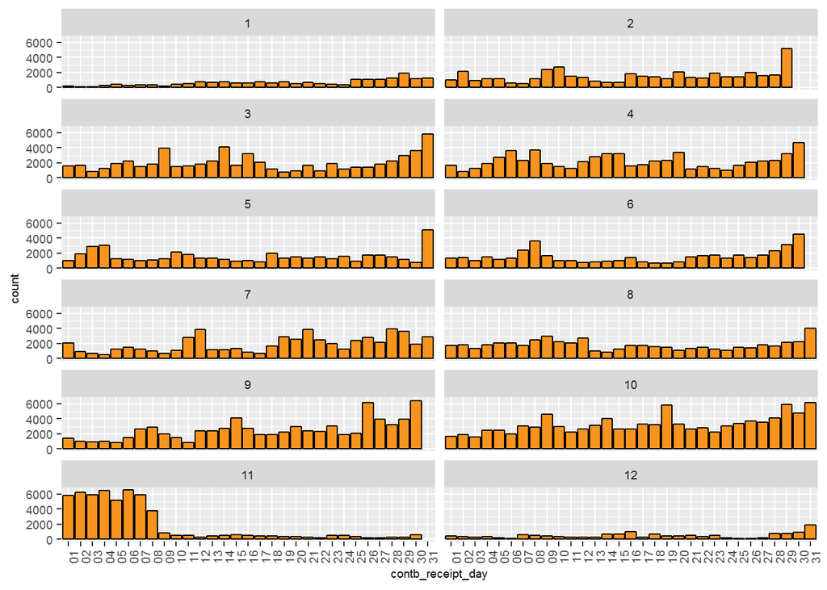

*What is the trend of of contribution through different years ?*

```
##   2013   2014   2015   2016
##      2     44  59966 589448
```

*plotting of contributions over different years in NY data set?*

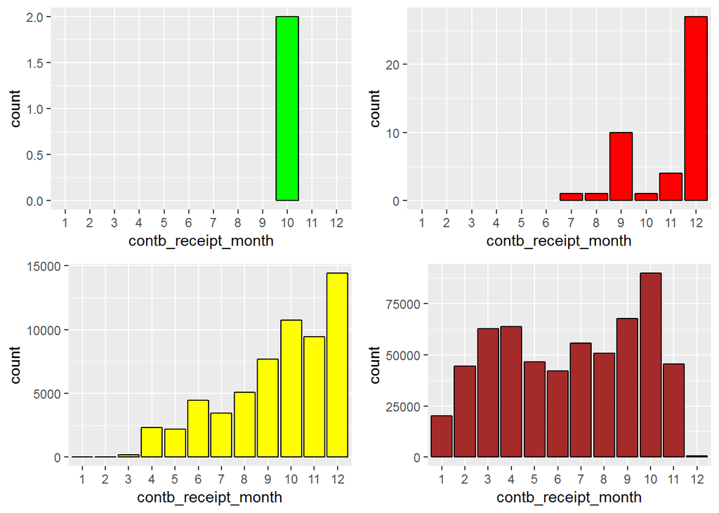

**NOTE**

*Number of contributions for 2013 and 2014 are only 46 contribution so it will excluded from analysis.*

**What is the monthly comparison for contributions count over 2015 and 2016 ?**

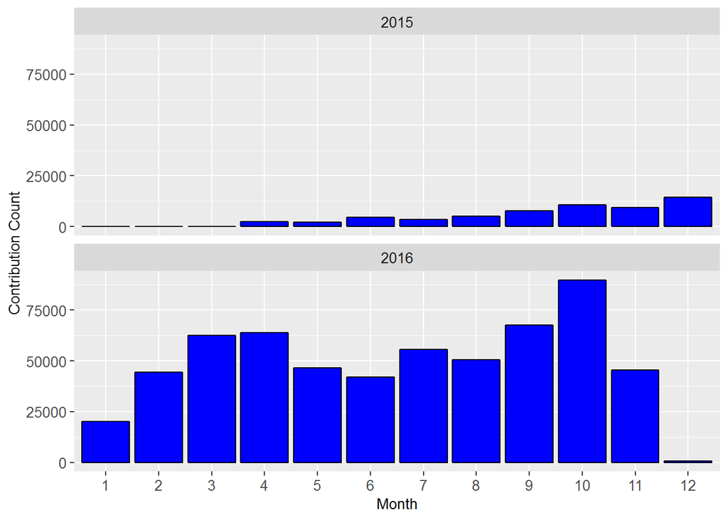

#### **Observations**

> 1- contributions in 2013 and 2014 are only 46 that is normal where there are no presidential election

> 2- preparation for presidential election start almost 18 month befor election and reach the maximum on october 2016

> 3- Number of contribution in the election year 2016 was 589448 which is almost 10 times greater than 2015 which it was 59966

### Contribution Receipt Amount, `contb_receipt_amt`

*What is the range of contribution in NY state ?*

```
##     Min.  1st Qu.   Median     Mean  3rd Qu.     Max.
##   -10100       15       27      264      100 12777706
```

```
## [1] 8002
```

> The Transaction amount `contb_receipt_amt` is widely distributed.  
> in the summary, the range from min to max values are from -10100 to 12777706.

*Is there any more negative Transaction in NY data set ?*

```
## [1] 867
```

*what is the range of this negative Transaction ?*

```
##      Min.   1st Qu.    Median      Mean   3rd Qu.      Max.
## -10100.00   -250.00    -80.00   -419.58    -25.00     -0.01
```

*why there are negative Transaction?*

`receipt_desc` and `memo_text` May be able to shed some light.

```
##
##                                                             7094
##                                           * HILLARY VICTORY FUND
##                                                              491
##                                         REDESIGNATION TO GENERAL
##                                                              406
##                                          REATTRIBUTION TO SPOUSE
##                                                              221
##                                 REDESIGNATION TO CRUZ FOR SENATE
##                                                              161
##                                                     CHARGED BACK
##                                                               91
##                            REDESIGNATION TO PRESIDENTIAL GENERAL
##                                                               12
##                                                REISSUED 12/16/16
##                                                                7
##                                               NSF/RETURNED CHECK
##                                                                6
##                                                 REISSUED ON 6/21
##                                                                5
##                                            * HILLARY ACTION FUND
##                                                                4
##                                           CHECK RETURNED BY BANK
##                                                                3
##                                         REDESIGNATION TO PRIMARY
##                                                                3
##                                               INSUFFICIENT FUNDS
##                                                                2
##                                                 REISSUED ON 6/27
##                                                                2
##                                      TRANSFER FROM RUBIO VICTORY
##                                                                2
##                    REFUND TO BE ISSUED; REDESIGNATION TO GENERAL
##                                                                1
##                                              REISSUED 10/16/2015
##                                                                1
##                       SEE REATTRIBUTION; REATTRIBUTION TO SPOUSE
##                                                                1
##                                                SEE REATTRIBUTION
##                                                                0
```

[output cut: 145 more lines]

```
##                                                                0
##       * EARMARKED CONTRIBUTION: SEE BELOW REFUNDED ON 10/17/2016
##                                                                0
##         * EARMARKED CONTRIBUTION: SEE BELOW REFUNDED ON 10/24/16
##                                                                0
##       * EARMARKED CONTRIBUTION: SEE BELOW REFUNDED ON 10/24/2016
##                                                                0
##        * EARMARKED CONTRIBUTION: SEE BELOW REFUNDED ON 10/7/2016
##                                                                0
##        * EARMARKED CONTRIBUTION: SEE BELOW REFUNDED ON 10/9/2016
##                                                                0
##            * EARMARKED CONTRIBUTION: SEE BELOW; REFUNDED 12/7/16
##                                                                0
##                                                          (Other)
##                                                                0
```

```
##
##                                                             1714
##                                                SEE REATTRIBUTION
##                                                                0
## * EARMARKED CONTRIBUTION: SEE BELOW REATTRIBUTION/REFUND PENDING
##                                                                0
##                          REATTRIBUTION / REDESIGNATION REQUESTED
##                                                                0
##              REATTRIBUTION / REDESIGNATION REQUESTED (AUTOMATIC)
##                                                                0
##                                        REATTRIBUTION FROM SPOUSE
##                                                                0
##                     REATTRIBUTION FROM SPOUSE; SEE REDESIGNATION
##                                                                0
##                                          REATTRIBUTION TO SPOUSE
##                                                              221
##                                REATTRIBUTION TO SPOUSE REQUESTED
##                                                                0
##                            REATTRIBUTION/REDESIGNATION REQUESTED
##                                                                0
##                                     REATTRIBUTION/REFUND PENDING
##                                                                0
##                                       REDESIGNATION FROM GENERAL
##                                                                0
##                                       REDESIGNATION FROM PRIMARY
##                                                                0
##       REDESIGNATION FROM PRIMARY; REFUNDED $350.00 ON 02/25/2016
##                                                                0
##                                REDESIGNATION FROM SENATE GENERAL
##                                                                0
##                                 REDESIGNATION TO CRUZ FOR SENATE
##                                                              161
##                                         REDESIGNATION TO GENERAL
##                                                              406
##                            REDESIGNATION TO PRESIDENTIAL GENERAL
##                                                               12
##                                         REDESIGNATION TO PRIMARY
##                                                                3
##                                                           Refund
##                                                             5994
##                    REFUND TO BE ISSUED REATTRIBUTION FROM SPOUSE
##                                                                0
##                  REFUND TO BE ISSUED; REDESIGNATION FROM PRIMARY
##                                                                0
##                    REFUND TO BE ISSUED; REDESIGNATION TO GENERAL
##                                                                1
##                                                SEE REATTRIBUTION
##                                                                0
##                            SEE REATTRIBUTION/REDESIGNATION BELOW
##                                                                0
##                       SEE REATTRIBUTION; REATTRIBUTION TO SPOUSE
##                                                                1
##                                                SEE REDESIGNATION
##                                                                0
```

*Now it is clear*

> The negative values comes from ’REFUND’s, ’REATTRIBUTION’s and ’REDESIGNATION’s.

*what is the summary of positive Transaction in NY data set ?*

```
##     Min.  1st Qu.   Median     Mean  3rd Qu.     Max.
##        0       15       27      273      100 12777706
```

*what is the summary of positive Transaction in NY data greater than 100$ ?*

```
##     Min.  1st Qu.   Median     Mean  3rd Qu.     Max.
##      100      200      250     1557     1000 12777706
```

*how many positive Transactions in NY data greater than 100$?*

```
## [1] 100034
```

*how much positive Transactions in NY data greater than 100$?*

```
## [1] 155763187
```

*how many positive Transactions in NY data less than 100$?*

```
## [1] 549426
```

*how much positive Transactions in NY data less than 100$?*

```
## [1] 15889700
```

*what are the number and amount of Transaction less than 100$ for every party ?*

```
## # A tibble: 5 x 3
##   cand_party  total_trans_l100 total_countl
##   <fct>                  <dbl>        <int>
## 1 Democratic         15609021.       494886
## 2 Republican           233065.        53441
## 3 Green                 25048           557
## 4 Libertarian           18376.          471
## 5 Independent            4190            71
```

*plotting for amount and count of transaction less than 100$*

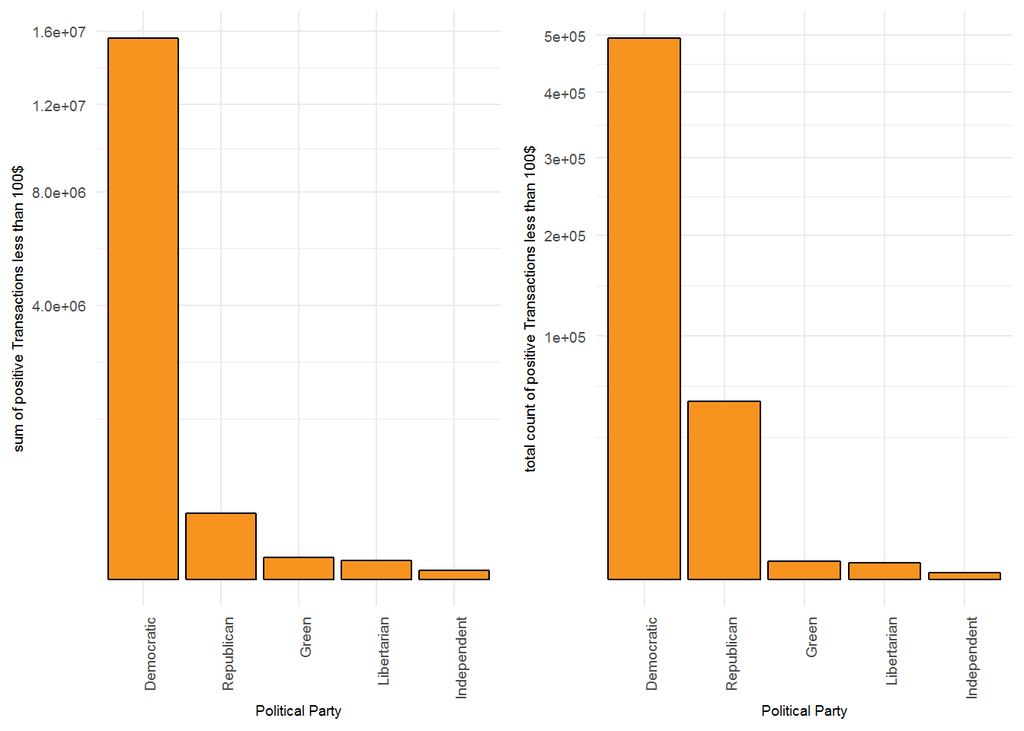

_

*what are the number and amount of Transaction greater than 100$ for every party ?*

```
## # A tibble: 5 x 3
##   cand_party  total_trans_g100 total_countg
##   <fct>                  <dbl>        <int>
## 1 Democratic        138043576.        79705
## 2 Republican         17226513.        19542
## 3 Green                238616.          444
## 4 Libertarian          228485.          311
## 5 Independent           25998.           32
```

*plotting for amount and count of transaction greater than 100$*

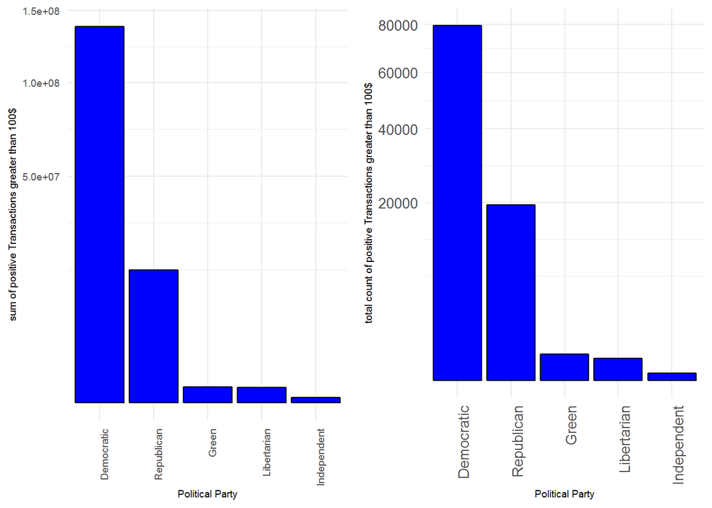

*comparing count of transaction between group less than 100$ and greater than 100$*

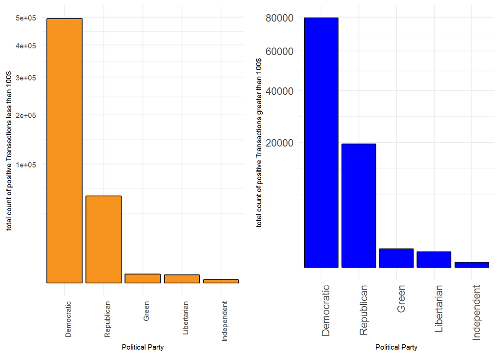

*comparing amount of transaction between group less than 100$ and greater than 100$*

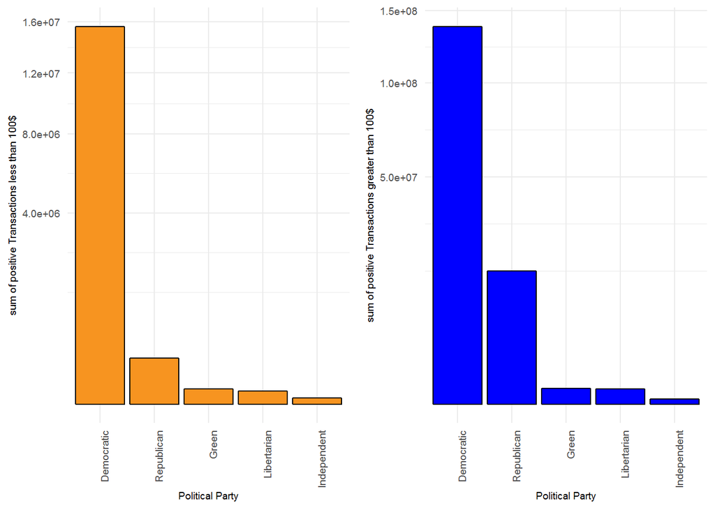

#### **Observations**

> 1- according to political party Democratic recive total number and amount of Transactions greater than all other parties

> 2- Number of Transactions less than 100$ almost 5 times greater than that more than 100$

> 3- Amount of Transactions more than 100 $ are greater than that less than 100$

> 5-Republican party recieve amount of Transactions more than 100$ vary dramatically than the amount of Transactions less than 100$

### Election Type `election_tp`

*What are unique values of Election Type?*

```
## [1] P2016 G2016       P2020 O2016 P2015
## Levels:  G2016 O2016 P2015 P2016 P2020
```

*How many unique values are for Election Type?*

```
## [1] 6
```

*How many contribution every type of election have ?*

```
##         G2016  O2016  P2015  P2016  P2020
##    690 271367    237      1 377162      3
```

*Below is a chart of `election_tp`.*

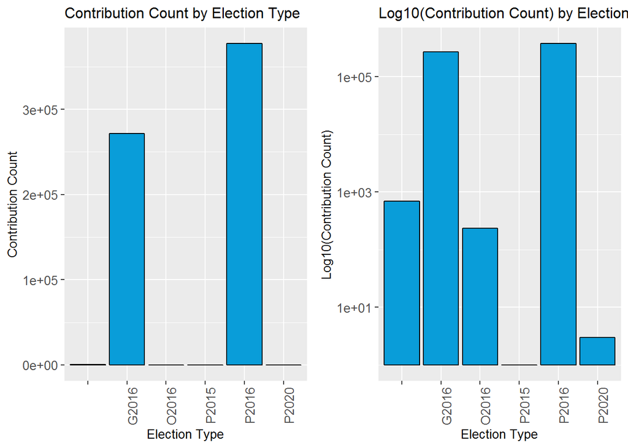

> It is interesting to note that there are already 3 transactions marked for the P2020 election. Most contributions are marked for the Presidential Election 2016, second by the General Election 2016. There are also 690 contributions without specifying election type data, and 237 marked for other election type.***

### Contributor City `contbr_city`

*How many cities contributions are come from ?*

```
## [1] 2327
```

*How maney contributions are come from every city?*

```
##           NEW YORK           BROOKLYN              BRONX
##             206993              86953              14102
##          ROCHESTER      STATEN ISLAND            BUFFALO
##               9985               7431               6196
##             ITHACA            ASTORIA             ALBANY
##               5840               5235               5225
##           SYRACUSE       WHITE PLAINS          SCARSDALE
##               3929               3700               3672
##       NEW ROCHELLE       FOREST HILLS   LONG ISLAND CITY
##               3366               3113               2973
##        SCHENECTADY            YONKERS          LARCHMONT
##               2749               2706               2590
##          CHAPPAQUA           FLUSHING   SARATOGA SPRINGS
##               2206               2166               2098
##       POUGHKEEPSIE         GREAT NECK         BRONXVILLE
##               2081               2049               2038
##            JAMAICA           WOODSIDE               TROY
##               1901               1826               1783
##           OSSINING              NYACK          PITTSFORD
##               1748               1702               1685
##    JACKSON HEIGHTS    PORT WASHINGTON           KINGSTON
##               1670               1633               1622
##       EAST HAMPTON HASTINGS ON HUDSON         LONG BEACH
##               1620               1604               1594
##         HUNTINGTON                RYE        MOUNT KISCO
##               1592               1517               1515
##             DELMAR          TARRYTOWN         BINGHAMTON
##               1461               1431               1423
##         SAG HARBOR        DOBBS FERRY            BAYSIDE
##               1286               1276               1245
##          RIDGEWOOD          DIX HILLS   CROTON ON HUDSON
##               1216               1210               1208
##          NEW PALTZ        PLATTSBURGH        STONY BROOK
##               1208               1203               1188
##         MAMARONECK          REGO PARK       MOUNT VERNON
##               1182               1170               1155
##          SUNNYSIDE            KATONAH             PELHAM
##               1140               1116               1089
##           NEW CITY          HARTSDALE   YORKTOWN HEIGHTS
##               1085               1045               1045
```

[output cut: 13 more lines]

```
##                882                881                871
##      WILLIAMSVILLE          IRVINGTON         MIDDLETOWN
##                868                866                862
##          WOODSTOCK        COLD SPRING            HAMBURG
##                854                846                842
##   BRIARCLIFF MANOR         QUEENSBURY HUNTINGTON STATION
##                838                835                832
##             BEACON   ROCKVILLE CENTRE            SYOSSET
##                827                826                820
##           NEWBURGH     EAST NORTHPORT        SOUTHAMPTON
##                802                801                789
##             LATHAM           FREEPORT           LYNBROOK
##                785                754                753
##            (Other)
##             175101
```

*What is the rankinking of cities that contribution come from*

```
## # A tibble: 2,327 x 4
##    contbr_city    city.rank count_of_contrib proportion
##    <fct>              <dbl>            <int>      <dbl>
##  1 NEW YORK      126888921.           206993    0.739
##  2 BROOKLYN        8884917.            86953    0.0518
##  3 SCARSDALE       1122942.             3672    0.00654
##  4 BRONX           1027972.            14102    0.00599
##  5 BUFFALO          752922.             6196    0.00439
##  6 STATEN ISLAND    690636.             7431    0.00402
##  7 LARCHMONT        660242.             2590    0.00385
##  8 ROCHESTER        639847.             9985    0.00373
##  9 RYE              585445.             1517    0.00341
## 10 CHAPPAQUA        570788.             2206    0.00333
## # ... with 2,317 more rows
```

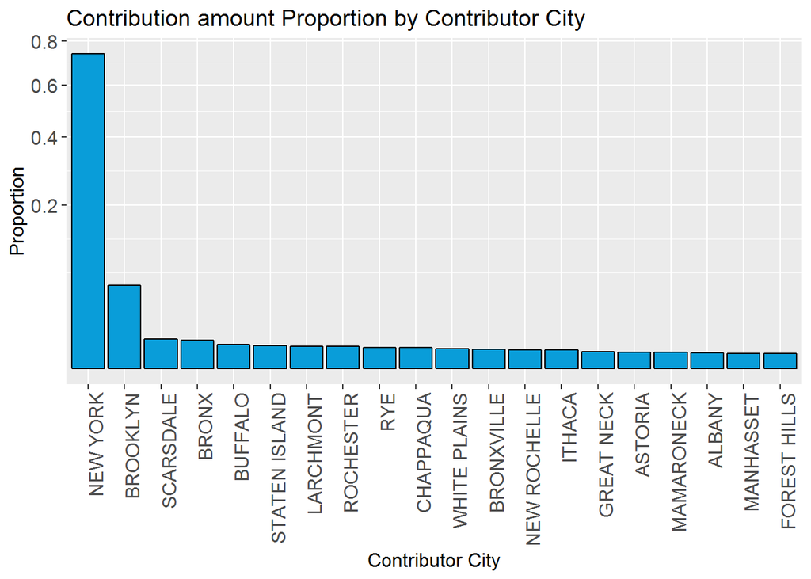

*There are 2327 different `contbr_city` where contribution come from. Most contributions*

```
    NEW YORK    206993

    BROOKLYN    86953
```

*Those accounts for about 45.3% of the contribution count.*

### Contributor Zip `contbr_zip`

> Since not all rows come with zip codes in full 9 digits, I decided to use the short version of zip for the EDA exercise. It’s added as an additional column, `contbr_zip_short` to NY dataset.

**how many Contributor Zip in NY data set** ?

```
## [1] 1936
```

*How many contributions every zip are recieve ?*

```
##   10025   10024   10023   10011   11201   11215   10003   10128   10014
##   17300   15736   15174   14712   12778   11981    9442    8967    8284
##   10028   10019   10021   10022   11238   10009   11217   10016   14850
##    8002    7344    7107    6953    6665    6277    6129    5853    5625
##   10001   10010   11231   10013   10012   10036   10065   10027   11211
##    5496    5367    5192    4730    4693    4640    4610    4269    4173
##   10002   10075   10463   10583   11218   11375   11222   10033   10026
##    4126    3803    3763    3672    3634    3172    2924    2910    2605
##   10538   11226   11209   10471   11216   11205   11249   12866   10514
##    2590    2586    2511    2491    2464    2449    2337    2242    2203
##   11746   10017   10029   10031   11743   10708   10591   10032   10038
##    2154    2097    2095    2067    2067    2055    2020    1997    1908
##   11101   11377   11050   11372   10040   11561   11225   10034   10018
##    1870    1857    1824    1819    1813    1797    1794    1780    1777
##   10562   11206   11106   10960   14534   11221   11385   10706   10549
##    1769    1767    1755    1752    1688    1677    1668    1658    1654
##   11937   10007   12180   12309   12203   12401   11733   10580   10804
##    1620    1587    1570    1569    1562    1531    1518    1517    1495
##   14618   12054   11230   11103   11105   11220   14221   10605   11237
##    1486    1462    1421    1398    1393    1374    1341    1328    1292
##   12208   11963   10522   10314   10520   11021   11104   11102   12561
##    1292    1290    1278    1275    1270    1252    1235    1212    1208
## (Other)
##  291524
```

*What is the rankinking of zipcodes that recieve contribution ?*

```
## # A tibble: 1,936 x 4
##    contbr_zip_short zip.amount.rank zip.amount.rank_n proportion
##    <fct>                      <dbl>             <int>      <dbl>
##  1 10185                  80693788.               186     0.470
##  2 10024                   3734380.             15736     0.0218
##  3 10023                   3604362.             15174     0.0210
##  4 10011                   3154627.             14712     0.0184
##  5 10128                   2807354.              8967     0.0164
##  6 10021                   2732262.              7107     0.0159
##  7 10025                   2498924.             17300     0.0146
##  8 10028                   2453040.              8002     0.0143
##  9 10022                   2434340.              6953     0.0142
## 10 11201                   2209214.             12778     0.0129
## # ... with 1,926 more rows
```

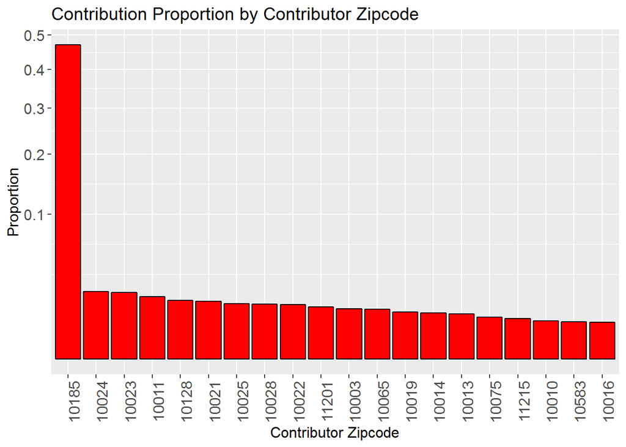

*1-There are 1936 distinct zipcodes.*

*2-most contribution from area with zipcode 10185 which is belong to NEW YORK state.*

### Contributor Employer `contbr_employer`

_** How many Contributor’s Employer in NY data set ?**_

```
## [1] 39304
```

**What is the rankinking of Contributor’s Employer ?**

```
## # A tibble: 39,304 x 4
##    contbr_employer       employer.rank contr_n proportion
##    <fct>                         <dbl>   <int>      <dbl>
##  1 ""                        78686343.    6183    0.458
##  2 SELF-EMPLOYED             12060419.   67025    0.0703
##  3 N/A                       10119157.   82294    0.0590
##  4 RETIRED                    4748780.   42105    0.0277
##  5 INFORMATION REQUESTED      3611890.   17049    0.0210
##  6 NOT EMPLOYED               1804569.   21881    0.0105
##  7 NONE                       1337244.   32333    0.00779
##  8 SELF EMPLOYED              1270093.   16453    0.00740
##  9 SELF                        942176.   15324    0.00549
## 10 HOMEMAKER                   928050.    1152    0.00541
## # ... with 39,294 more rows
```

*A chart of proportion of contributions from the top 10 Contributor’s Employer.*

[figure not shown]

#### **Observations**

*There are 39304 distinct employers.*

**4- RETIRED , NOT EMPLOYED , NONE , SELF EMPLOYED , HOMEMAKER , SELF may be contributors refuse to provide the employer information**

### Contributor Occupation `contbr_occupation`

**How many Contributor’s Occupation are interested to contribute ?**

```
## [1] 17220
```

*for more details we can use this code line*

```r
#summary(ny$contbr_occupation)
```

```
## # A tibble: 17,220 x 4
##    contbr_occupation     occupation.rank contr_n proportion
##    <fct>                           <dbl>   <int>      <dbl>
##  1 ""                          78701231.    6266    0.458
##  2 RETIRED                     10094554.   98667    0.0588
##  3 ATTORNEY                     7094876.   26486    0.0413
##  4 INFORMATION REQUESTED        3756409.   16956    0.0219
##  5 LAWYER                       3202851.   10011    0.0187
##  6 NOT EMPLOYED                 2856234.   47994    0.0166
##  7 HOMEMAKER                    2850488.    7689    0.0166
##  8 CONSULTANT                   1837758.    8878    0.0107
##  9 PHYSICIAN                    1705536.   10897    0.00994
## 10 CEO                          1619854.    2562    0.00944
## # ... with 17,210 more rows
```

*A chart of percentage of contributions from the top 10 contributor’s occupation .*

[figure not shown]

## Final Univariate Analysis

**1. What is the structure of dataset?**

> There are 649460 contribution transaction records in the dataset with 18 variables (cmte_id, cand_id, cand_nm, contbr_nm, contbr_city, contbr_st, contbr_zip, contbr_employer, contbr_occupation, contb_receipt_amt, contb_receipt_dt, receipt_desc, memo_cd, memo_text, form_tp, file_num, trans_id, election_tp).

> All these variables are unordered variables, except for contb_receipt_amt (num) and file_num (int).

**2. What is/are the main feature(s) of interest in dataset?**

> The main features in the dataset are contribution date, contribution amount, candidate name and candidate party affiliation (a variable I added). The other variables may have impact on predicting the contribution amount.

**3. What other features in the dataset do you think will help support your investigation into your feature(s) of interest?**

> other variables like contributor city, contributor zip, contributor occupation may have impact on the contribution amount. However, for project I decided to focus on candidate names, candidate party affiliation and contribution date, and may be a bit on contributor city.

**4. Did you create any new variables from existing variables in the dataset?**

> Party affiliation for each candidate was identified and added as `cand_party`. The dates `contb_receipt_dt` were originally in factor type. The column was converted to Date type. They were also broken down the date into `contb_receipt_day`, `contb_receipt_month`, `contb_receipt_month_name`, and `contb_receipt_year`.  
> The data in `contbr_zip` was not consistent. Additional variable `contbr_zip_short` was added to only extract the first 5 digit of `contbr_zip`. `file_num` was also converted into factor type but not analyzed.

**5. Of the features you investigated, were there any unusual distributions? Did you perform any operations on the data to tidy, adjust, or change the form of the data? If so, why did you do this?**

> Log10 and sqrt transformation were performed on `cand_nm`, `cand_party` `contb_receipt_amt`,`contbr_nm`,`contbr_zip`and `contbr_occupation`.  
> The log10 transformation on `cand_nm` helped easily filter out the vast differences of contribution counts by each candidate.  
> The log10 transformation on `contb_receipt_amt` helped shape sekewed chart into a somewhat normal distribution

## *Bivariate Plots*

*Sum of Contribution Amount received by Candidates*

```
## # A tibble: 25 x 9
##    cand_nm      n sum_amt   mean    max    min median count_proportion
##    <fct>    <int>   <dbl>  <dbl>  <dbl>  <dbl>  <dbl>            <dbl>
##  1 Clinto~ 399522  1.45e8  364.  1.28e7  -5400   27           0.615
##  2 Sander~ 174564  8.05e6   46.1 5.40e3  -6579   27           0.269
##  3 Trump,~  36931  5.72e6  155.  1.00e4  -9300   59.2         0.0569
##  4 Bush, ~   2436  3.59e6 1473.  5.40e3  -5400 2400           0.00375
##  5 Rubio,~   4813  2.39e6  496.  1.08e4  -5400  100           0.00741
##  6 Cruz, ~  16785  1.65e6   98.1 1.08e4 -10100   35           0.0258
##  7 Kasich~   1350  8.65e5  641.  5.00e3  -2700  250           0.00208
##  8 Christ~    486  8.61e5 1772.  6.00e3  -5400 2700           0.000748
##  9 Carson~   6638  6.35e5   95.7 5.40e3  -3300   50           0.0102
## 10 Graham~    362  3.53e5  975.  7.70e3  -2700 1000           0.000557
## # ... with 15 more rows, and 1 more variable: sum_proportion <dbl>
```

*Ranking for sum of contribution received for the top 10 candidates (by sum of contribution amount).*

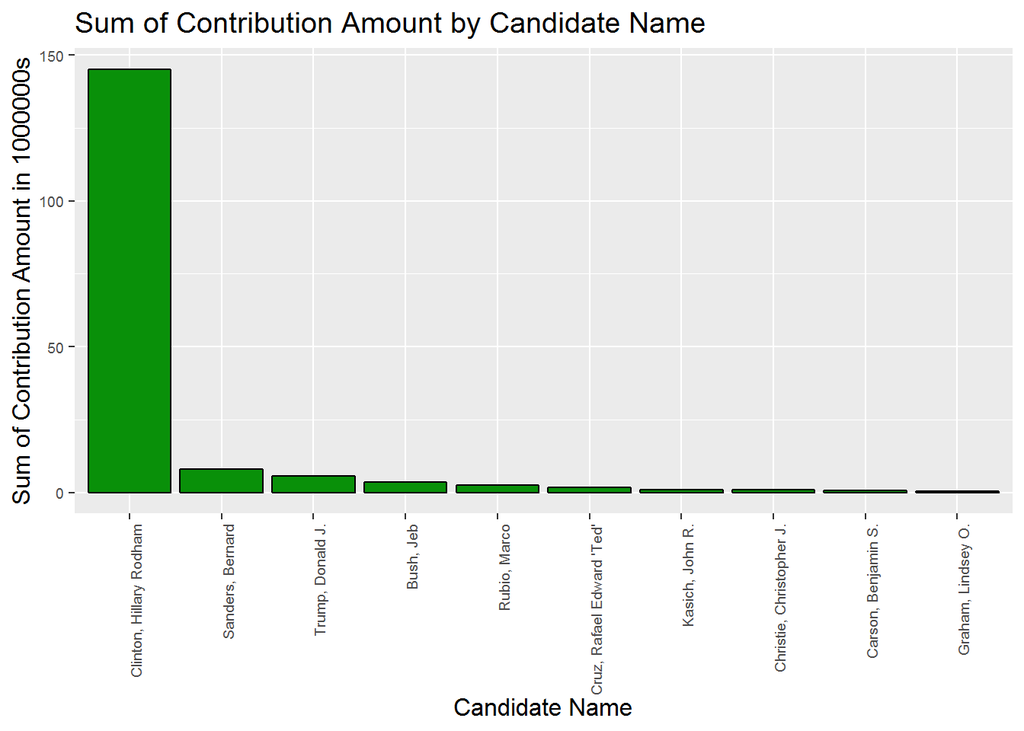

*Who are the top 5 candidates received contribution*

```
## [1] Clinton, Hillary Rodham Sanders, Bernard        Trump, Donald J.
## [4] Bush, Jeb               Rubio, Marco
## 25 Levels: Bush, Jeb Carson, Benjamin S. ... Webb, James Henry Jr.
```

### Distribution of Contribution Receipt Amount by Top 5 Candidates

```
##                     cand_nm     contb_receipt_amt        n
##  Clinton, Hillary Rodham:4817   Min.   :   -9300   Min.   :    1.00
##  Sanders, Bernard       :2525   1st Qu.:      33   1st Qu.:    1.00
##  Trump, Donald J.       :1769   Median :      87   Median :    1.00
##  Rubio, Marco           : 190   Mean   :    8789   Mean   :   65.86
##  Bush, Jeb              :  86   3rd Qu.:     193   3rd Qu.:    3.00
##  Carson, Benjamin S.    :   0   Max.   :12777706   Max.   :76262.00
##  (Other)                :   0
##     cum_amt
##  Min.   : -488700
##  1st Qu.:      55
##  Median :     161
##  Mean   :   17577
##  3rd Qu.:     456
##  Max.   :25709400
##
```

*Boxplot for distribution of contribution amounts received for the top 5 candidates (by sum of contribution amount).*

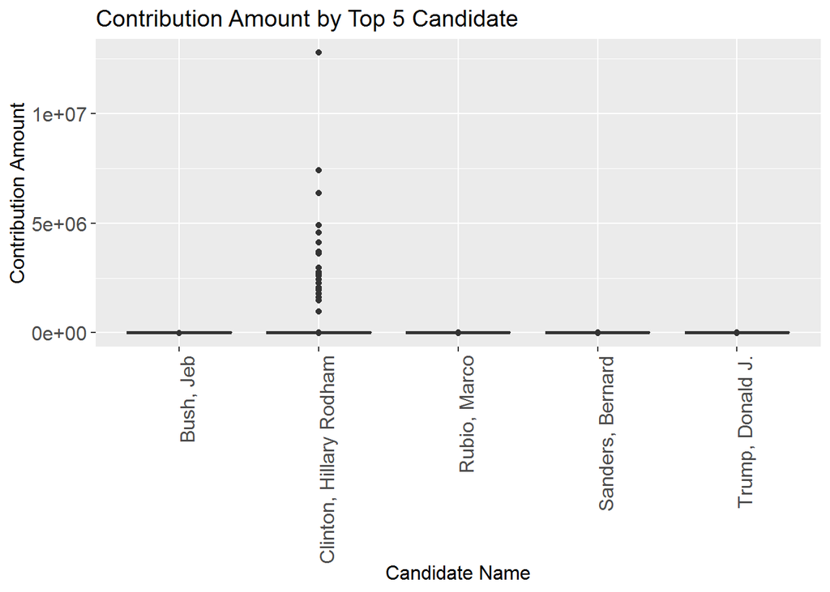

```
## ny_subset_top5_cand_nm_by_amt$cand_nm: Bush, Jeb
##    Min. 1st Qu.  Median    Mean 3rd Qu.    Max.
##   -5400     100    2400    1473    2700    5400
## --------------------------------------------------------
## ny_subset_top5_cand_nm_by_amt$cand_nm: Carson, Benjamin S.
## NULL
## --------------------------------------------------------
## ny_subset_top5_cand_nm_by_amt$cand_nm: Christie, Christopher J.
## NULL
## --------------------------------------------------------
## ny_subset_top5_cand_nm_by_amt$cand_nm: Clinton, Hillary Rodham
##     Min.  1st Qu.   Median     Mean  3rd Qu.     Max.
##    -5400       15       27      364      100 12777706
## --------------------------------------------------------
## ny_subset_top5_cand_nm_by_amt$cand_nm: Cruz, Rafael Edward 'Ted'
## NULL
## --------------------------------------------------------
## ny_subset_top5_cand_nm_by_amt$cand_nm: Fiorina, Carly
## NULL
## --------------------------------------------------------
## ny_subset_top5_cand_nm_by_amt$cand_nm: Gilmore, James S III
## NULL
## --------------------------------------------------------
## ny_subset_top5_cand_nm_by_amt$cand_nm: Graham, Lindsey O.
## NULL
## --------------------------------------------------------
## ny_subset_top5_cand_nm_by_amt$cand_nm: Huckabee, Mike
## NULL
## --------------------------------------------------------
## ny_subset_top5_cand_nm_by_amt$cand_nm: Jindal, Bobby
## NULL
## --------------------------------------------------------
## ny_subset_top5_cand_nm_by_amt$cand_nm: Johnson, Gary
## NULL
## --------------------------------------------------------
## ny_subset_top5_cand_nm_by_amt$cand_nm: Kasich, John R.
## NULL
## --------------------------------------------------------
## ny_subset_top5_cand_nm_by_amt$cand_nm: Lessig, Lawrence
## NULL
```

[output cut: 24 more lines]

```
## ny_subset_top5_cand_nm_by_amt$cand_nm: Santorum, Richard J.
## NULL
## --------------------------------------------------------
## ny_subset_top5_cand_nm_by_amt$cand_nm: Stein, Jill
## NULL
## --------------------------------------------------------
## ny_subset_top5_cand_nm_by_amt$cand_nm: Trump, Donald J.
##     Min.  1st Qu.   Median     Mean  3rd Qu.     Max.
## -9300.00    28.00    59.18   154.86   147.20 10000.00
## --------------------------------------------------------
## ny_subset_top5_cand_nm_by_amt$cand_nm: Walker, Scott
## NULL
## --------------------------------------------------------
## ny_subset_top5_cand_nm_by_amt$cand_nm: Webb, James Henry Jr.
## NULL
```

*using ylim to exclude some outliers such as in Clinton, Hillary Rodham*

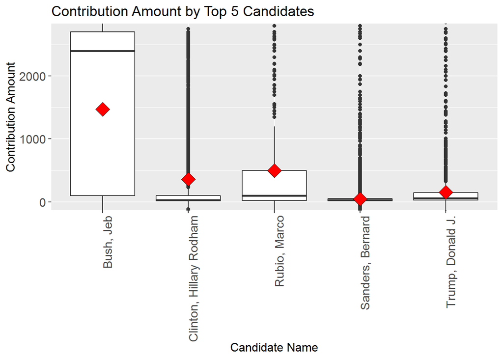

### Sum of Contribution Receipt Amount by Party Affiliation

```
## # A tibble: 5 x 9
##   cand_party      n sum_amt  mean    max     min median count_proportion
##   <fct>       <int>   <dbl> <dbl>  <dbl>   <dbl>  <dbl>            <dbl>
## 1 Democratic 574591  1.54e8  267. 1.28e7 -6.58e3   27           0.885
## 2 Republican  72983  1.75e7  239. 1.18e4 -1.01e4   50           0.112
## 3 Green        1001  2.64e5  263. 2.80e3  2.50e0  100           0.00154
## 4 Libertari~    782  2.47e5  316. 2.70e3 -1.50e2   79.5         0.00120
## 5 Independe~    103  3.02e4  293. 2.70e3  1.00e0  100           0.000159
## # ... with 1 more variable: sum_proportion <dbl>
```

*Barchart of sum of contribution amount received by every party affiliation.*

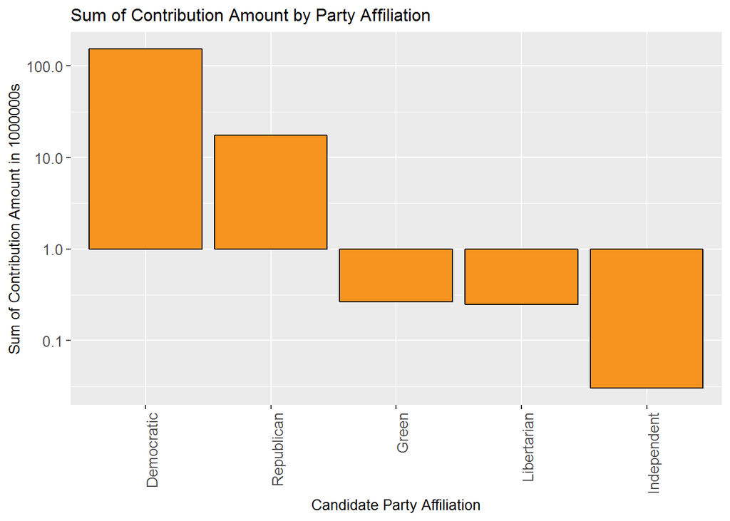

### Distribution of Contribution Receipt Amount by Candidate Party Affiliation

```
##        cand_party   contb_receipt_amt        n
##  Democratic :6569   Min.   :  -10100   Min.   :    1.00
##  Green      :  74   1st Qu.:      35   1st Qu.:    1.00
##  Independent:  26   Median :      90   Median :    1.00
##  Libertarian:  89   Mean   :    9275   Mean   :   73.01
##  Republican :2137   3rd Qu.:     200   3rd Qu.:    3.00
##                     Max.   :12777706   Max.   :87539.00
##     cum_amt
##  Min.   :-1279800
##  1st Qu.:      61
##  Median :     172
##  Mean   :   19298
##  3rd Qu.:     472
##  Max.   :26114400
```

*Boxplot for distribution of contribution amounts received by each party affiliation.*

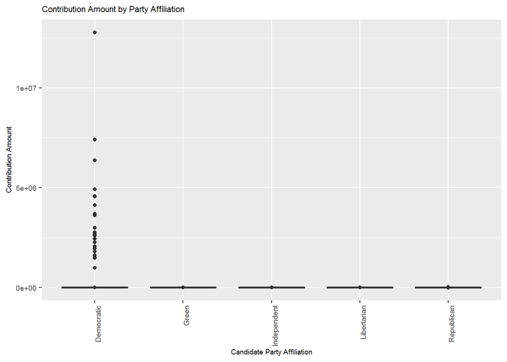

```
## ny$cand_party: Democratic
##     Min.  1st Qu.   Median     Mean  3rd Qu.     Max.
##    -6579       15       27      267       79 12777706
## --------------------------------------------------------
## ny$cand_party: Green
##    Min. 1st Qu.  Median    Mean 3rd Qu.    Max.
##     2.5    29.0   100.0   263.4   250.0  2800.0
## --------------------------------------------------------
## ny$cand_party: Independent
##    Min. 1st Qu.  Median    Mean 3rd Qu.    Max.
##     1.0    50.0   100.0   293.1   250.0  2700.0
## --------------------------------------------------------
## ny$cand_party: Libertarian
##    Min. 1st Qu.  Median    Mean 3rd Qu.    Max.
## -150.00   25.00   79.48  315.68  250.00 2700.00
## --------------------------------------------------------
## ny$cand_party: Republican
##     Min.  1st Qu.   Median     Mean  3rd Qu.     Max.
## -10100.0     25.0     50.0    239.2    146.0  11816.2
```

*using ylim to exclude some outliers such as in Democratic*

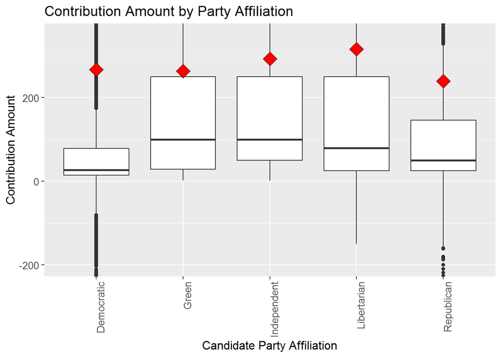

### Sum of Contribution Receipt Amount by Top 20 Cities

```
## # A tibble: 2,327 x 9
##    contbr_city      n sum_amt  mean    max   min median count_proportion
##    <fct>        <int>   <dbl> <dbl>  <dbl> <dbl>  <dbl>            <dbl>
##  1 NEW YORK    206993  1.27e8 613.  1.28e7 -9300   40            0.319
##  2 BROOKLYN     86953  8.88e6 102.  1.08e4 -7300   27            0.134
##  3 SCARSDALE     3672  1.12e6 306.  7.30e3 -5400   50            0.00565
##  4 BRONX        14102  1.03e6  72.9 5.40e3 -2700   25            0.0217
##  5 BUFFALO       6196  7.53e5 122.  6.40e3 -2700   28            0.00954
##  6 STATEN ISL~   7431  6.91e5  92.9 2.70e3 -2700   27            0.0114
##  7 LARCHMONT     2590  6.60e5 255.  5.40e3 -2700   50            0.00399
##  8 ROCHESTER     9985  6.40e5  64.1 5.40e3 -3200   25            0.0154
##  9 RYE           1517  5.85e5 386.  5.40e3 -5400   67.6          0.00234
## 10 CHAPPAQUA     2206  5.71e5 259.  5.40e3 -2700   50            0.00340
## # ... with 2,317 more rows, and 1 more variable: sum_proportion <dbl>
```

*Barchart of sum of contribution received from top 20 contributor cities (by sum of contribution received).*

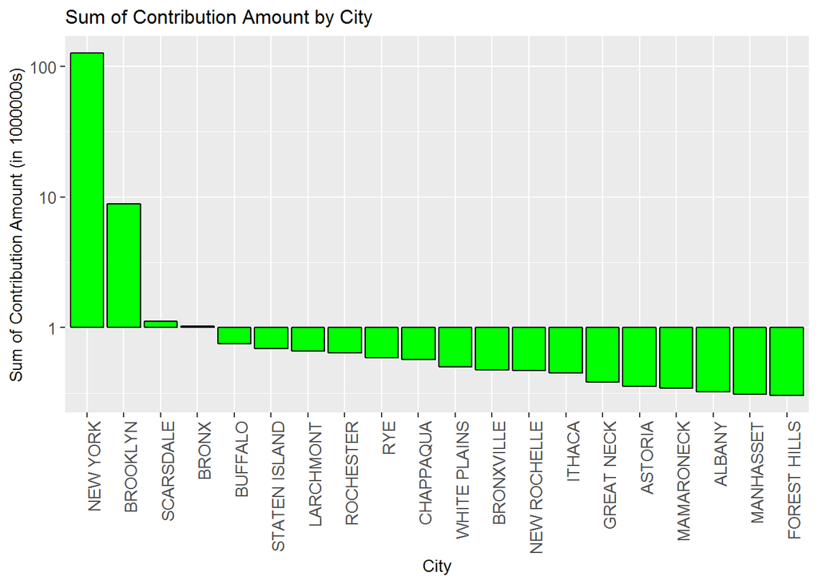

*subset for top20_city and top10_city according to amount of contributions*

```r
top20_city <- ny.sum_contb_receipt_amt_by_contbr_city[1:20,]

ny_subset_top20_city_by_amt <- ny[ny$contbr_city %in% top20_city$contbr_city,]

top10_city <- ny.sum_contb_receipt_amt_by_contbr_city[1:10,]
ny_subset_top10_city_by_amt <- ny[ny$contbr_city %in% top10_city$contbr_city,]
```

### Distribution of Contribution Receipt Amount by Top 20 Cities

*Boxplot for distribution of contribution amounts received for the top 20 cities (by sum of contribution amount).*

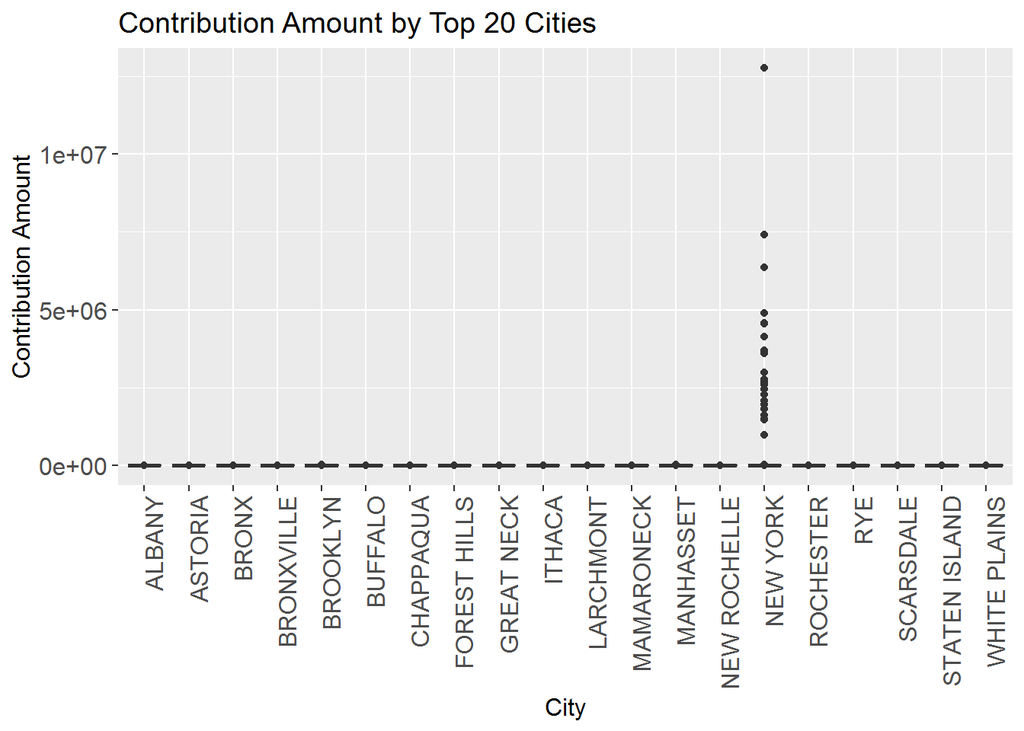

```
##       cmte_id            cand_id                            cand_nm
##  C00575795:260638   P00003392:260638   Clinton, Hillary Rodham  :260638
##  C00577130: 90038   P60007168: 90038   Sanders, Bernard         : 90038
##  C00580100:  9649   P80001571:  9649   Trump, Donald J.         :  9649
##  C00574624:  4485   P60006111:  4485   Cruz, Rafael Edward 'Ted':  4485
##  C00458844:  2495   P60006723:  2495   Rubio, Marco             :  2495
##  C00579458:  1701   P60008059:  1701   Bush, Jeb                :  1701
##  (Other)  :  5337   (Other)  :  5337   (Other)                  :  5337
##              contbr_nm             contbr_city     contbr_st
##  BODNICK, KATIE   :  1326   NEW YORK     :206993   NY:374343
##  BRUN, GINA       :   413   BROOKLYN     : 86953
##  BRONER, NAHAMA   :   318   BRONX        : 14102
##  SCHWARTZ, HILARY :   311   ROCHESTER    :  9985
##  KILLORIN, MICHAEL:   310   STATEN ISLAND:  7431
##  GRODY, GORDON    :   307   BUFFALO      :  6196
##  (Other)          :371358   (Other)      : 42683
##      contbr_zip          contbr_employer      contbr_occupation
##  100015704:  1332   SELF-EMPLOYED: 46892   RETIRED     : 42205
##  10024    :  1143   N/A          : 42997   NOT EMPLOYED: 21285
##  10022    :   844   RETIRED      : 14536   ATTORNEY    : 19619
##  10025    :   803   NONE         : 13373   LAWYER      :  7937
##  10023    :   788   NOT EMPLOYED : 10922   TEACHER     :  7342
##  10128    :   710   (Other)      :245462   (Other)     :275918
##  (Other)  :368723   NA's         :   161   NA's        :    37
##  contb_receipt_amt   contb_receipt_dt                      receipt_desc
##  Min.   :   -9300   06-NOV-16:  4067                             :369239
##  1st Qu.:      15   02-NOV-16:  4016   Refund                    :  4043
##  Median :      30   26-SEP-16:  3979   REDESIGNATION TO GENERAL  :   217
##  Mean   :     389   07-NOV-16:  3879   REDESIGNATION FROM PRIMARY:   214
##  3rd Qu.:     100   04-NOV-16:  3823   REATTRIBUTION FROM SPOUSE :   102
##  Max.   :12777706   31-OCT-16:  3811   REATTRIBUTION TO SPOUSE   :   102
##                     (Other)  :350768   (Other)                   :   426
##  memo_cd                                  memo_text      form_tp=ny
##   :314873                                      :232958   SA17A:312255
##  X: 59470   * EARMARKED CONTRIBUTION: SEE BELOW: 88512   SA18 : 58045
##             * HILLARY VICTORY FUND             : 50085   SB28A:  4043
##             * HILLARY ACTION FUND              :   521
##             *BEST EFFORTS UPDATE               :   413
##             REDESIGNATION TO GENERAL           :   217
##             (Other)                            :  1637
```

[output cut: 9 more lines]

```
##  29     : 19814    2013:     0        OCT    : 61958
##  30     : 18347    2014:    22        SEP    : 47730
##  31     : 15903    2015: 33467        APR    : 36212
##  08     : 14704    2016:340854        NOV    : 34375
##  28     : 14559                       MAR    : 34026
##  26     : 14375                       JUL    : 32682
##  (Other):276641                       (Other):127360
##  contb_receipt_month contbr_zip_short
##  10     : 61958      10025  : 17249
##  9      : 47730      10024  : 15678
##  4      : 36212      10023  : 15096
##  11     : 34375      10011  : 14675
##  3      : 34026      11201  : 12353
##  7      : 32682      11215  : 11980
##  (Other):127360      (Other):287312
```

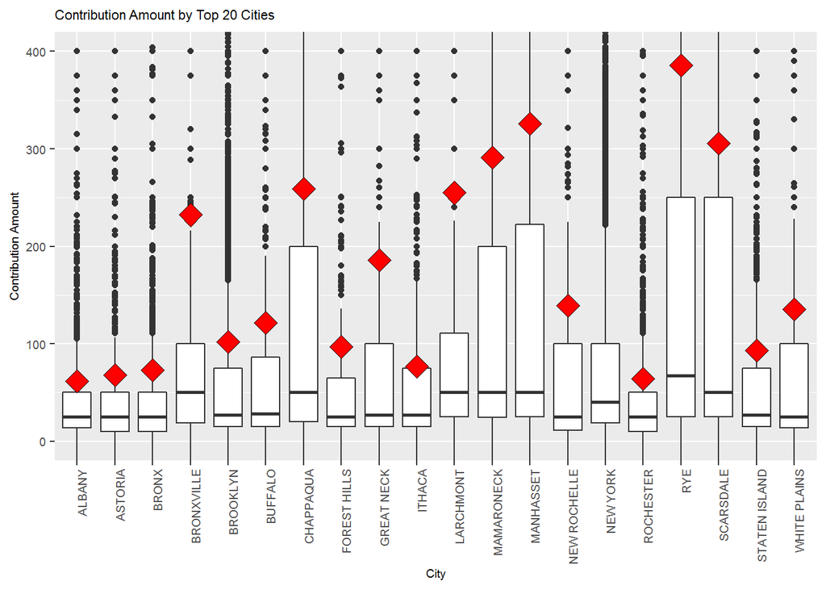

### Sum of Contribution Receipt Amount by Contribution Year, Month, day and Date

```
## # A tibble: 697 x 9
##    contb_receipt_dt     n sum_amt  mean    max    min median
##    <fct>            <int>   <dbl> <dbl>  <dbl>  <dbl>  <dbl>
##  1 31-JUL-16         2643  1.31e7 4944. 1.28e7 -5400    50
##  2 30-JUN-16         3741  7.80e6 2086. 7.40e6 -6700    28
##  3 24-AUG-16          895  6.51e6 7270. 6.36e6 -1000    25
##  4 31-MAR-16         5768  5.26e6  911. 4.90e6 -2700    27
##  5 29-SEP-16         3412  4.97e6 1458. 4.56e6 -2700    35
##  6 31-MAY-16         5010  4.89e6  977. 4.58e6 -3892.   27
##  7 13-OCT-16         2164  4.43e6 2047. 4.13e6  -800    34.8
##  8 29-FEB-16         5156  4.09e6  793. 3.69e6 -2700    27
##  9 29-APR-16         3152  3.81e6 1208. 3.60e6 -2853.   25
## 10 19-OCT-16         5271  3.51e6  665. 2.98e6 -2000    37
## # ... with 687 more rows, and 2 more variables: count_proportion <dbl>,
## #   sum_proportion <dbl>
```

```
## # A tibble: 697 x 11
##    contb_receipt_y~ contb_receipt_m~ contb_receipt_d~     n sum_amt  mean
##    <fct>            <fct>            <fct>            <int>   <dbl> <dbl>
##  1 2016             7                31                2643  1.31e7 4944.
##  2 2016             6                30                3741  7.80e6 2086.
##  3 2016             8                24                 895  6.51e6 7270.
##  4 2016             3                31                5768  5.26e6  911.
##  5 2016             9                29                3412  4.97e6 1458.
##  6 2016             5                31                5010  4.89e6  977.
##  7 2016             10               13                2164  4.43e6 2047.
##  8 2016             2                29                5156  4.09e6  793.
##  9 2016             4                29                3152  3.81e6 1208.
## 10 2016             10               19                5271  3.51e6  665.
## # ... with 687 more rows, and 5 more variables: max <dbl>, min <dbl>,
## #   median <dbl>, count_proportion <dbl>, sum_proportion <dbl>
```

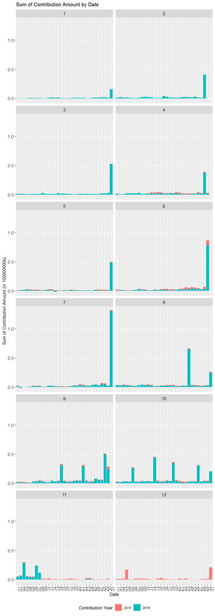